# Raport z zadania na 4.5

Marta Jóźwik, Ewa Baranowska

20 kwietnia 2017

# 1 Wyniki ogólne dla każdego z działów

Policzyłyśmy na podstawie plausible values wyniki wszystkich rozważanych uczniów w każdym dziale w zależności od strategii, którą przyjęli. Poniższy wykres przedstawia te informacje. Widać z niego, że strategia 4 (najpierw szybko, potem wolno, gepardy), niezależnie od działu jest najefektywniejsza, również strategia 3 ( sprinterzy, wszystko szybko) okazuje się skuteczna.

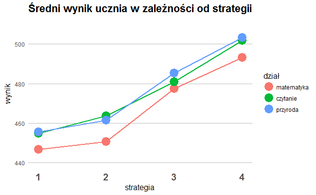

# 2 Wyniki ogólne dla każdego z działów w podziale na kraje

## 2.1 Matematyka

Przeprowadziłyśmy analizę wariancji dla wyników z matematyki w podziale na kraje i strategie. Czynnikiem były strategie, hipoteza zerowa zakładała, że obrana strategia nie ma wpływu na osiągane wyniki. Po przeprowadzeniu testu na poziomie istotności 0.05 odrzucamy hipotezę zerową (wartość statystyki testowej: 6.5, przy odpowiednim kwantylu rozkładu F-Snedecora 2.7), stwierdzamy więc że obrana strategia ma wpływ na osiągnięte wyniki z matematyki. Na poniższym wykresie można zauważyć zróżnicowanie wyników w zależności od obranej strategii dla każdego kraju.

[interactive chart not shown]

## 2.2 Czytanie

Taką samą analizę wariancji przeprowadzamy dla wyników z czytania. Po przeprowadzeniu testu na poziomie istotności 0.05 odrzucamy hipotezę zerową (wartość statystyki testowej: 12, przy odpowiednim kwantylu rozkładu F-Snedecora 2.7), również stwierdzamy że obrana strategia ma wpływ na osiągnięte wyniki z czytaniai. Poniższy wykres obrazuje zróżnicowanie wyników dla każdego kraju.

[interactive chart not shown]

## 2.3 Przyroda

Kolejna analiza dla wyników z przyrody również skutkuje odrzuceniem hipotezy zerowej (wartość statystyki testowej: 9.5, przy odpowiednim kwantylu rozkładu F-Snedecora 2.7), a więc i w przypadku ptzyrody obrana strategia ma wpływ na osiągnięte wyniki. Poniżej wykres zróżnicowania wyników w zależności od strategii.

[interactive chart not shown]

## 2.4 Wyniki dla wybranych krajów

Dla 3 wybranych krajów, reprezentujących każdą z grup widoczną na powyższych wykresach i dla Polski wyrysowałyśmy konkretne wartości na poniższym wykresie. Widać z niego, że rzeczywiście 4 strategia jest najlepsza dla każdego z wybranych krajów, natomiast skuteczność pozostalych strategii jest już różna w różnych krajach.

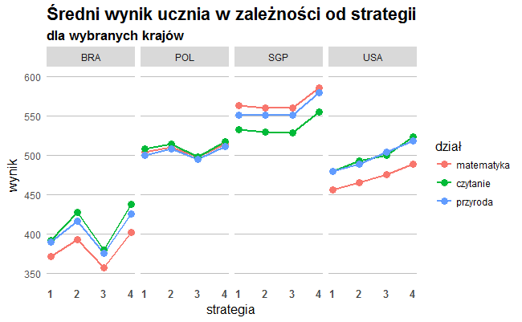

# 3 Zmiany w rankingu po uwzględnieniu wpływu strategii

Żeby uwzględnić wpływ strategii w wynikach danego kraju, policzyłyśmy średni wynik (plausible values), licząc średnią ze średnich wyników dla poszczególnych strategii w danym kraju, oraz średni wynik licząc średnią z wszystkich obserwacji (tak jak w oryginalnym rankingu). Z obu średnich stworzyłyśmy 2 rankingi, w których zmiany pozycji dla każdego kraju zaznaczyłyśmy odpowiednim kolorem i nachyleniem linii.

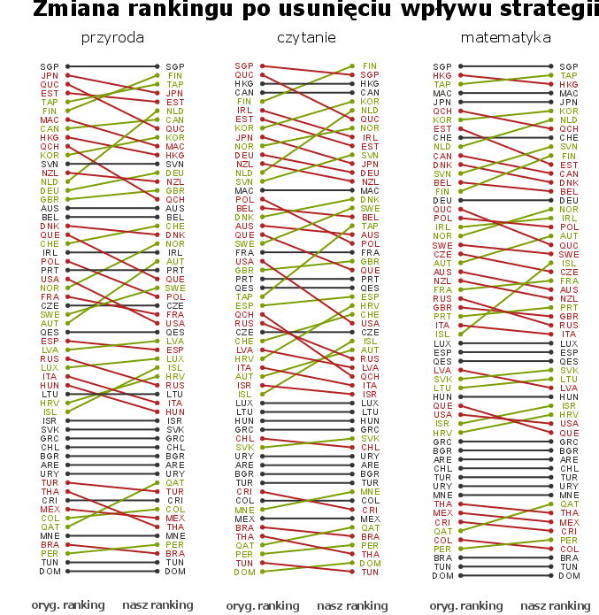

Z wykresu widać, że dla każdego działu pozycja Polski spada, gdy usuniemy wpływ strategii. Widać również, że usunięcie wpływu strategii zaburza ranking, choć różnicę między przyjmowanymi pozycjami nie są ogromne. Singapur, który prowadzi w oryginalnym rankingu nadal pozostaje w pierwszej dwójce.

# 4 Skrypty

### 4.0.1 Z_4_5_1.R

```r
setwd("C:/Users/E540/Desktop/PISA 2015/zadanie0/")
load("Z4_stud_strategie.rda" )

library(dplyr)
library(tidyr)
library(ggplot2)

#### wyniki ogolne

dane_strategie %>% group_by(strategia) %>% summarise( wynik_mat = sum(W_FSTUWT*PV1MATH)/sum(W_FSTUWT),
                                                      wynik_read = sum(W_FSTUWT*PV1READ)/sum(W_FSTUWT),
                                                      wynik_scien = sum(W_FSTUWT*PV1SCIE)/sum(W_FSTUWT)
                                                    ) -> wyniki_ogolne
wyniki_ogolne_spread <- gather(wyniki_ogolne, dzial, wynik, wynik_mat:wynik_scien )

p <- ggplot(data=wyniki_ogolne_spread, aes(x=strategia, y=wynik, color=as.factor(dzial)))+geom_line(size=1)+
   geom_point(size=6)+
   ggtitle("Średni wynik ucznia w zależności od strategii")+
   scale_color_discrete(name = "dział", labels=c("matematyka", "czytanie", "przyroda")) +
   theme(title = element_text(size=18, face='bold'),
         axis.title.y = element_text(size=12, face='plain'),
         axis.title.x =  element_text(size=12, face='plain'),
         panel.background = element_blank(),
         panel.grid.major = element_line(colour="grey"),
         axis.ticks = element_line(colour="white"),
         axis.text.x = element_text(size=14,face='bold'),
         panel.grid.major.x =element_blank(),
         legend.key=element_blank(),
         legend.title = element_text(size=12, face='plain')
         )+
    scale_y_continuous(limits=c(440,510),breaks=seq(440,500,20))
p

### wyniki dla krajow

dane_strategie %>% group_by(strategia,CNT) %>% summarise( wynik_mat = sum(W_FSTUWT*PV1MATH)/sum(W_FSTUWT),
                                                      wynik_read = sum(W_FSTUWT*PV1READ)/sum(W_FSTUWT),
                                                      wynik_scien = sum(W_FSTUWT*PV1SCIE)/sum(W_FSTUWT)
) -> wyniki_kraje


library(d3heatmap)


doHeatmapyM <- wyniki_kraje[,c("strategia", "CNT", "wynik_mat")]
doHeatmapyM <- spread(doHeatmapyM, key=strategia,wynik_mat)
doHeatmapyM1  <-as.matrix(doHeatmapyM[,2:5])
rownames(doHeatmapyM1) <- doHeatmapyM$CNT

heatmapaM <- d3heatmap(doHeatmapyM1, colors = "YlOrRd", k_row = 3,
                      labCol = c("leniwiec", "maratonczyk", "sprinter", "gepard"), dendrogram = "row",
                      cexRow = 0.8, digits = 2, brush_color = "#0000ff"
)
heatmapaM

dane <- doHeatmapyM

# liczenie srednich w grupach i po calosci
dane<-t(dane[,c(2:5)])
srednie_kol <- apply(dane, 2, mean)
srednia <- mean(as.matrix(dane))
SSB<-sum((srednie_kol-srednia)^2)*4
mac_wart<-dane
SST<-sum((mac_wart-srednia)^2)
mac_kol<-rep(srednie_kol,4)
mac_kol<-matrix(mac_kol,nrow=4,byrow=T)
SSA<-sum((mac_wart-mac_kol)^2)
#zgadza sie SSA+SSB=SST

stat=(SSA/3)/(SSB/(57*4))

1-pf(stat,3,57*3)
#1,450



### wyniki dla wybranych krajow

wyniki_kraje_4 <- wyniki_kraje[wyniki_kraje$CNT %in% c("POL", "SGP", "BRA", "USA"),]


wyniki_kraje_4 <- gather(wyniki_kraje_4, dzial, wynik, wynik_mat:wynik_scien )

p <- ggplot(data=wyniki_kraje_4, aes(x=strategia, y=wynik, color=as.factor(dzial)))+geom_line(size=1)+
   geom_point(size=3)+
   ggtitle("Średni wynik ucznia w zależności od strategii",subtitle = "dla wybranych krajów")+
   scale_color_discrete(name = "dział", labels=c("matematyka", "czytanie", "przyroda")) +
   theme(title = element_text(size=18, face='bold'),
         axis.title.y = element_text(size=12, face='plain'),
         axis.title.x =  element_text(size=12, face='plain'),
         panel.background = element_blank(),
         panel.grid.major = element_line(colour="grey"),
         axis.ticks = element_line(colour="white"),
         axis.text.x = element_text(size=10,face='bold'),
         panel.grid.major.x =element_blank(),
         legend.key=element_blank(),
         legend.title = element_text(size=12, face='plain')
   )+
   scale_y_continuous(limits=c(350,600),breaks=seq(350,600,50))+
   facet_grid(.~CNT)
p



wyniki_M<-wyniki_kraje[,1:3]





dane_strategie %>% group_by(CNT) %>% summarise( strat1 = sum(W_FSTUWT[strategia == 1])/sum(W_FSTUWT)*100,
                                                strat2 = sum(W_FSTUWT[strategia == 2])/sum(W_FSTUWT)*100,
                                                strat3 = sum(W_FSTUWT[strategia == 3])/sum(W_FSTUWT)*100,
                                                strat4 = sum(W_FSTUWT[strategia == 4])/sum(W_FSTUWT)*100
) -> strategie_kraje

a<-gather(strategie_kraje, key = strategia,wynik, strat1:strat4)
a$strategia<-ifelse(a$strategia=="strat1",1,ifelse(a$strategia=="strat2",2,ifelse(a$strategia=="strat3",3,4)))
wyniki_M<-merge(wyniki_M,a,by=c("CNT","strategia"))

colnames(wyniki_M)<-c("CNT","strategia","wynik","ilosc_proc")


wyniki_M_usrednione<-wyniki_M %>% group_by(CNT) %>% summarize(wynik=sum(wynik*25)/100)
wyniki_M_prawdziwe<-wyniki_M %>% group_by(CNT) %>% summarize(wynik=sum(wynik*ilosc_proc)/100)

wyniki_M_wyjsciowe<-merge(wyniki_M_prawdziwe,wyniki_M_usrednione,by="CNT")
colnames(wyniki_M_wyjsciowe)<-c("CNT","prawdziwe","bez_wplywu")

wyniki_M_wyjsciowe %>% arrange(prawdziwe) %>% mutate(ranking1 = row_number()) ->wyniki_M_wyjsciowe
wyniki_M_wyjsciowe %>% arrange(bez_wplywu) %>% mutate(ranking2 = row_number()) ->wyniki_M_wyjsciowe
wyniki_M_wyjsciowe$kolorek <- ifelse(wyniki_M_wyjsciowe$ranking1 == wyniki_M_wyjsciowe$ranking2, "steelblue",
                             ifelse(wyniki_M_wyjsciowe$ranking1 > wyniki_M_wyjsciowe$ranking2, "red",
                                    "green")
)

wyniki_M_wyjsciowe <- gather(wyniki_M_wyjsciowe, ranking, pozycja, ranking1,ranking2)


p <- ggplot(data=wyniki_M_wyjsciowe, aes(x=as.numeric(as.factor(ranking)), y=pozycja,group=CNT, label=CNT, color=kolorek))+geom_line(size=1)+
   geom_point(size=2)+geom_text(nudge_x = ifelse(wyniki_M_wyjsciowe$ranking =="ranking2",0.2,-0.2),show.legend = FALSE)+
   ggtitle("Zmiana w rankingu po uwzględnieniu wpływu strategii") +
   theme(title = element_text(size=18, face='bold'),
         axis.title.x =  element_blank(),
         panel.background = element_blank(),
         panel.grid.major = element_blank(),
         axis.ticks = element_line(colour="white"),
         axis.text.x = element_text(size=14,face='bold'),
         axis.text.y = element_blank(),
         axis.title.y = element_blank(),
         panel.grid.major.x =element_blank(),
         legend.key=element_blank(),
         legend.title = element_text(size=12, face='plain'),
         legend.position="none"
   )+scale_x_continuous(limits=c(0.5,4), breaks=c(1,2), labels = c("oryg. ranking", "nasz ranking"))+
   scale_color_manual(values=c("#7b9f01", "firebrick","grey20"))
p
```